# Single Cell Analysis for TetON Cells

Sandra Vidak/Gianluca Pegoraro

June 24th 2022

### Introduction

Columbus screen names:

`20191008-40x-TetON-GRP78-Calnexin-PDI-SUN2-LAP2a-LB1-H3K27-H4K16-gH2AX_20191008_114604`

`20191009-40x-TetON-Hsp110-Calnexin-Hsc70-SUN1_20191009_125328`

`20191010-40x-TetON-Hsp110-GRP94-Calnexin-Hsp70-SUN1-Hsp40-Hsp90_20191010_144805`

### Analysis Setup

Load required packages.

```r
library(tidyverse)
library(fs)
library(Hmisc)
library(ggthemes)
library(DescTools) # for Dunnett's Test
```

```r
source("R/Plotters.R") #Functions needed for plotting
```

Set the palette and the running theme for ggplot2.

### Experimental Metadata

Read plate layouts.

```r
cell_levs <- c("Uninduced", "2d", "4d", "6d")

plate_layouts <- read_tsv("metadata/plate_layout.txt") %>%
  filter(!is.na(cell_line)) %>%
  separate(col = cell_line,
           into = c("cell_line"),
           remove = T) %>%
  mutate(cell_line = factor(cell_line, levels = cell_levs))

glimpse(plate_layouts)
```

```
## Rows: 12
## Columns: 4
## $ row       <dbl> 2, 3, 4, 5, 6, 7, 8, 9, 10, 11, 12, 13
## $ column    <dbl> 5, 5, 5, 5, 5, 5, 5, 5, 5, 5, 5, 5
## $ marker    <chr> "Calnexin", "Calnexin", "Calnexin", "Calnexin", "Calnexin", ~
## $ cell_line <fct> Uninduced, Uninduced, Uninduced, 2d, 2d, 2d, 4d, 4d, 4d, 6d,~
```

Plot plate layouts.

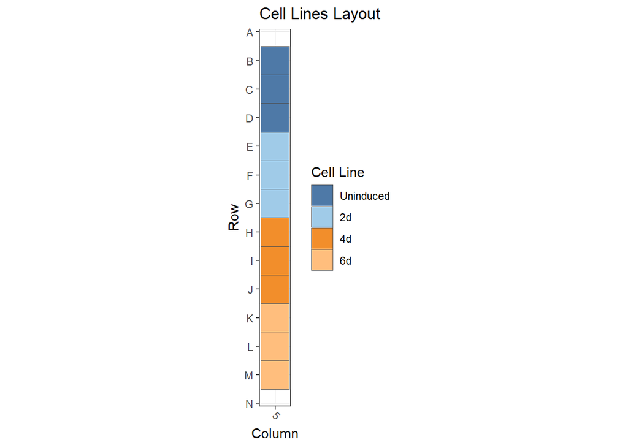

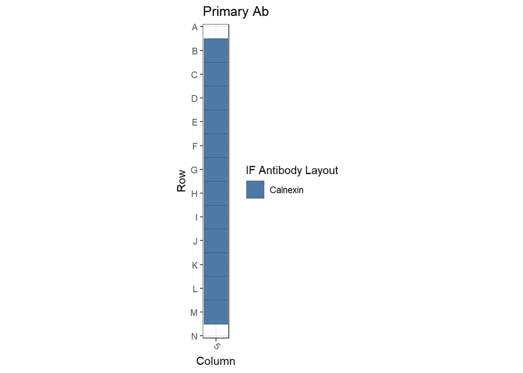

### Read and Process Columbus data

Recursively search the `data` directory and its subdirectories for files whose name includes the Glob patterns defined in the chunk above, and read the cell-level Columbus data from the results text files.

```r
read_columbus_results <- function(path, glob) {
  dir_ls(path = path,
         recurse = T,
         glob = glob)  %>%
    read_tsv(
      id = "file_name"
    ) %>%
    select(
      screen = ScreenName,
      plate = PlateName,
      well = WellName,
      row = Row,
      column = Column,
      nuc_area = `Nuclei Selected - Nucleus Area [px²]`,
      cyto_area = `Nuclei Selected - Cytoplasm Area [px²]`,
      cell_area = `Nuclei Selected - Cell Area [px²]`,
      nuc_marker_int = `Nuclei Selected - Intensity Nucleus BP600/37 Mean`,
      cyto_marker_int = `Nuclei Selected - Intensity Cytoplasm BP600/37 Mean`,
      ratio_marker_int = `Nuclei Selected - Nuc_Cyto_BP600_Ratio`
    )
}

glob_path <- "*- Nuclei Selected[0].txt"
col_tbl <- read_columbus_results("data", glob_path)

glimpse(col_tbl)
```

```
## Rows: 398,519
## Columns: 11
## $ screen           <chr> "20191008-40x-TetON-GRP78-Calnexin-PDI-SUN2-LAP2a-LB1~
## $ plate            <chr> "AssayPlate_PerkinElmer_CellCarrier-384 Ultra", "Assa~
## $ well             <chr> "B10", "B10", "B10", "B10", "B10", "B10", "B10", "B10~
## $ row              <dbl> 2, 2, 2, 2, 2, 2, 2, 2, 2, 2, 2, 2, 2, 2, 2, 2, 2, 2,~
## $ column           <dbl> 10, 10, 10, 10, 10, 10, 10, 10, 10, 10, 10, 10, 10, 1~
## $ nuc_area         <dbl> 1413, 2736, 1687, 1831, 1605, 2219, 1884, 1133, 1678,~
## $ cyto_area        <dbl> 635, 1802, 987, 785, 400, 3999, 2148, 1789, 1204, 218~
## $ cell_area        <dbl> 2048, 4538, 2674, 2616, 2005, 6218, 4032, 2922, 2882,~
## $ nuc_marker_int   <dbl> 2605.95, 3068.62, 2836.78, 3005.06, 2383.19, 2485.38,~
## $ cyto_marker_int  <dbl> 857.346, 567.685, 748.230, 796.290, 1288.730, 472.500~
## $ ratio_marker_int <dbl> 3.03955, 5.40551, 3.79132, 3.77383, 1.84926, 5.26007,~
```

Join Columbus data with the plate layout information.

```r
cell_tbl <- col_tbl %>%
  mutate(sum_marker_int = nuc_marker_int + cyto_marker_int) %>%
  inner_join(plate_layouts,
             by = c("row", "column")) %>%
  select(screen,
         plate,
         well,
         row,
         column,
         cell_line,
         marker,
         nuc_area:sum_marker_int)

glimpse(cell_tbl)
```

```
## Rows: 54,739
## Columns: 14
## $ screen           <chr> "20191008-40x-TetON-GRP78-Calnexin-PDI-SUN2-LAP2a-LB1~
## $ plate            <chr> "AssayPlate_PerkinElmer_CellCarrier-384 Ultra", "Assa~
## $ well             <chr> "B5", "B5", "B5", "B5", "B5", "B5", "B5", "B5", "B5",~
## $ row              <dbl> 2, 2, 2, 2, 2, 2, 2, 2, 2, 2, 2, 2, 2, 2, 2, 2, 2, 2,~
## $ column           <dbl> 5, 5, 5, 5, 5, 5, 5, 5, 5, 5, 5, 5, 5, 5, 5, 5, 5, 5,~
## $ cell_line        <fct> Uninduced, Uninduced, Uninduced, Uninduced, Uninduced~
## $ marker           <chr> "Calnexin", "Calnexin", "Calnexin", "Calnexin", "Caln~
## $ nuc_area         <dbl> 1535, 1497, 1857, 1178, 1457, 1784, 1784, 3784, 3694,~
## $ cyto_area        <dbl> 1733, 1470, 1130, 1475, 361, 4289, 2824, 3453, 2282, ~
## $ cell_area        <dbl> 3268, 2967, 2987, 2653, 1818, 6073, 4608, 7237, 5976,~
## $ nuc_marker_int   <dbl> 777.584, 858.843, 722.836, 747.350, 575.962, 690.992,~
## $ cyto_marker_int  <dbl> 747.992, 867.456, 647.116, 870.219, 679.463, 750.281,~
## $ ratio_marker_int <dbl> 1.039560, 0.990071, 1.117010, 0.858807, 0.847673, 0.9~
## $ sum_marker_int   <dbl> 1525.576, 1726.299, 1369.952, 1617.569, 1255.425, 144~
```

```r
well_tbl <- cell_tbl %>%
  group_by(screen,
           well,
           row,
           column,
           cell_line,
           marker) %>%
  summarise(cell_n = n(),
            across(nuc_area:sum_marker_int,
                   list(mean = ~ mean(.x, na.rm = T))))

glimpse(well_tbl)
```

```
## Rows: 36
## Columns: 14
## Groups: screen, well, row, column, cell_line [36]
## $ screen                <chr> "20191008-40x-TetON-GRP78-Calnexin-PDI-SUN2-LAP2~
## $ well                  <chr> "B5", "C5", "D5", "E5", "F5", "G5", "H5", "I5", ~
## $ row                   <dbl> 2, 3, 4, 5, 6, 7, 8, 9, 10, 11, 12, 13, 2, 3, 4,~
## $ column                <dbl> 5, 5, 5, 5, 5, 5, 5, 5, 5, 5, 5, 5, 5, 5, 5, 5, ~
## $ cell_line             <fct> Uninduced, Uninduced, Uninduced, 2d, 2d, 2d, 4d,~
## $ marker                <chr> "Calnexin", "Calnexin", "Calnexin", "Calnexin", ~
## $ cell_n                <int> 1517, 1500, 1439, 1552, 1570, 1534, 1547, 1484, ~
## $ nuc_area_mean         <dbl> 2447.960, 2594.614, 2421.129, 2564.855, 2516.934~
## $ cyto_area_mean        <dbl> 3207.858, 3102.757, 3404.315, 3040.876, 3088.581~
## $ cell_area_mean        <dbl> 5655.819, 5697.371, 5825.443, 5605.731, 5605.515~
## $ nuc_marker_int_mean   <dbl> 692.1245, 944.9945, 1219.5997, 1486.5361, 1488.8~
## $ cyto_marker_int_mean  <dbl> 680.6082, 914.9898, 1107.5799, 1185.2150, 1158.1~
## $ ratio_marker_int_mean <dbl> 1.0312435, 1.0385160, 1.1143746, 1.2658496, 1.29~
## $ sum_marker_int_mean   <dbl> 1372.8040, 1859.9843, 2327.1795, 2671.7512, 2648~
```

Calculate the mean of the technical replicates for each biological replicate. Now every marker/cell line combination has an n = 3 biological replicates.

```r
bioreps_tbl <- well_tbl %>%
  group_by(screen,
           cell_line,
           marker) %>%
  summarise(across(cell_n:sum_marker_int_mean,
                    ~ mean(.x, na.rm = T)))

glimpse(bioreps_tbl)
```

```
## Rows: 12
## Columns: 11
## Groups: screen, cell_line [12]
## $ screen                <chr> "20191008-40x-TetON-GRP78-Calnexin-PDI-SUN2-LAP2~
## $ cell_line             <fct> Uninduced, 2d, 4d, 6d, Uninduced, 2d, 4d, 6d, Un~
## $ marker                <chr> "Calnexin", "Calnexin", "Calnexin", "Calnexin", ~
## $ cell_n                <dbl> 1485.333, 1552.000, 1549.333, 1392.000, 1566.667~
## $ nuc_area_mean         <dbl> 2487.901, 2553.150, 2088.838, 2234.419, 2614.918~
## $ cyto_area_mean        <dbl> 3238.310, 3119.837, 3490.909, 3898.686, 2979.976~
## $ cell_area_mean        <dbl> 5726.211, 5672.987, 5579.747, 6133.105, 5594.894~
## $ nuc_marker_int_mean   <dbl> 952.2395, 1507.7621, 2591.6216, 2680.9962, 438.2~
## $ cyto_marker_int_mean  <dbl> 901.0593, 1182.0566, 1347.0043, 1530.7511, 457.7~
## $ ratio_marker_int_mean <dbl> 1.0613781, 1.2875850, 2.0293355, 1.8212491, 0.96~
## $ sum_marker_int_mean   <dbl> 1853.3226, 2690.2026, 3938.6259, 4211.7549, 896.~
```

### Biological Replicates Level plot for Fig.1D

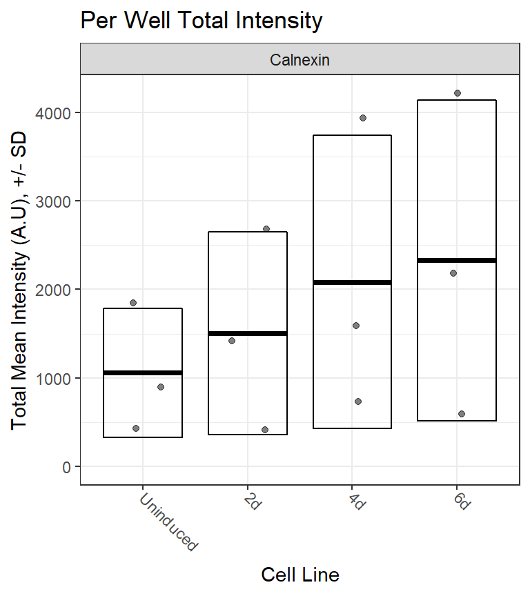

### Calculate Dunnett’s test for the continuous variables.

```r
calc_dunnett <- function(df){
  as.data.frame(as.table(DunnettTest(ratio_marker_int_mean ~ cell_line,
                          control = "Uninduced",
                          data = df)$Uninduced)) %>%
    pivot_wider(names_from = Var2, values_from = Freq) %>%
    rename(comparison = Var1)
}
```

Run the custom function on all the data grouped based on the IF marker and save the data to a .csv file.

```r
dunnett_test <- bioreps_tbl %>%
  group_by(marker) %>%
  group_modify(~ calc_dunnett(.x))

write_csv(dunnett_test, "output/dunnett_results.csv")

knitr::kable(dunnett_test, digits = 3)
```

| marker | comparison | diff | lwr.ci | upr.ci | pval |
| --- | --- | --- | --- | --- | --- |
| Calnexin | 2d-Uninduced | 0.236 | -0.098 | 0.571 | 0.174 |
| Calnexin | 4d-Uninduced | 0.908 | 0.573 | 1.242 | 0.000 |
| Calnexin | 6d-Uninduced | 0.675 | 0.340 | 1.009 | 0.001 |